```r
library(data.table)
library(igraph)
library(stringr)
library(splitstackshape)
library(plotly)
library(network)
library(lubridate)
library(readxl)
library(lubridate)
library(dplyr)
library(PearsonDS)
library(parallel)
library(doParallel)
library(Matrix)
```

```r
#import the data
districts = fread("C:/Users/10331/OneDrive/Desktop/election_results.csv", header=TRUE)
border = fread("C:/Users/10331/OneDrive/Desktop/border_information.csv", header=TRUE)
rain = fread("C:/Users/10331/OneDrive/Desktop/yearly_rainfall_with_spi.csv", header=TRUE)
```

Hi, please check out this note while grading!!!

The setup provided by Prof and TA is not working. Probably because Prof Lewis has changed the data and questions.

The two columns: adj_new_party and adj_total_party are empty in table districts_adjrain

So I had to create my own adj_new_party and adj_total_party to solve the question, which makes the process really messy.

Please try to be more patient with the lengthy code, because I really spend a lot of effort to create those variables since the setup is not working.

Thank you so much!!!!!!!!!!!!!!!!!!!!!!!!!!!!! <<<3

```r
#find all unique years and election periods
years = sort(unique(districts$year))
election_periods = c(list(seq(1946,1951)), lapply(seq_along(years)[-1], function(i) seq(years[i-1] +1, years[i])))
```

```r
#transform into a datatable
rain_year = data.table(rain)

#see what type of extreme weathers happened each year
rain_year[, moderately_dry := as.numeric(spi < -1)]
rain_year[, severely_dry := as.numeric(spi < -1.5)]
rain_year[, extremely_dry := as.numeric(spi < -2)]
rain_year[, moderately_wet := as.numeric(spi > 1)]
rain_year[, severely_wet := as.numeric(spi > 1.5)]
rain_year[, extremely_wet := as.numeric(spi > 2)]
rain_year[, moderately_abnormal := as.numeric( (spi > 1)| (spi < -1))]
rain_year[, severely_abnormal := as.numeric( (spi > 1.5)| (spi <-1.5))]
rain_year[, extremely_abnormal := as.numeric((spi>2)| (spi<-2))]
```

```r
# create a huge list with weather data for each election periods
# each element is a data table of rain_year table associated within the election period
rain_elections = lapply(seq_along(election_periods), function(i) rain_year[year %in% election_periods[[i]]])

spicols = colnames(rain_year)[(ncol(rain_year)-8):ncol(rain_year)]
```

```r
# for each district, calculate the sum of each SPI column
rain_elections = lapply(seq_along(election_periods), function(i)
  rain_elections[[i]][, (spicols):=lapply(.SD, function(x)
    sum(x)), .SDcols = spicols, by = district])

# calculate the yearly avg spi for each district
rain_elections = lapply(seq_along(election_periods), function(i) rain_elections[[i]][,spi := mean(spi), by=district])

# have the latest year of each election period as the representative year
rain_elections = lapply(seq_along(election_periods), function(i) rain_elections[[i]][, year := as.integer((max(election_periods[[i]])), by = district)])

# calculate the sum of the rain
rain_elections = lapply(seq_along(election_periods), function(i) rain_elections[[i]][, rain := sum(rain), by = district])

# remove the duplicated rows and select columns about drought
spi_elections = lapply(seq_along(election_periods), function(i) unique(rain_elections[[i]][, list(moderately_dry = moderately_dry, severely_dry = severely_dry, extremely_dry = extremely_dry, moderately_wet = moderately_wet, severely_wet = severely_wet, extremely_wet = extremely_wet, moderately_abnormal = moderately_abnormal, severely_abnormal = severely_abnormal, extremely_abnormal = extremely_abnormal, spi = spi, year = year, rain = rain, district = district,  election_periods = i)]))

spi_elections = rbindlist(spi_elections)
```

```r
#merge the weather data with the election data
setkeyv(spi_elections, c("district","year"))
setkeyv(districts, c('district','year'))

districts = merge(districts, spi_elections)

head(districts, n=10)
```

```
##     district year          state              name gender age
##  1: Adilabad 1951 Andhra Pradesh   C. MADHAV REDDY      ? -99
##  2: Adilabad 1951 Andhra Pradesh  J. V. NARSINGRAO      ? -99
##  3: Adilabad 1957 Andhra Pradesh   C. MADHAV REDDY      ? -99
##  4: Adilabad 1957 Andhra Pradesh        K. ASHANNA      ? -99
##  5: Adilabad 1962 Andhra Pradesh  G. NARAYAN REDDY      M -99
##  6: Adilabad 1962 Andhra Pradesh   MOHD. PAKRUDDIN      M -99
##  7: Adilabad 1962 Andhra Pradesh RAM RAO DESHPANDE      M -99
##  8: Adilabad 1962 Andhra Pradesh    V.G. DORA SAMI      M -99
##  9: Adilabad 1967 Andhra Pradesh            D. RAO      M -99
## 10: Adilabad 1967 Andhra Pradesh          D.S. RAO      M -99
##                   party_name party_issue party_scope vote_count language unrest
##  1:          SOCIALIST PARTY    far left    national      90995   Telugu      0
##  2: Indian National Congress     liberal    national      65912   Telugu      0
##  3:    PRAJA SOCIALIST PARTY    far left    national      85375   Telugu      0
```

[output cut: 40 more lines]

```r
# by make a flipped copy of the paris in boarder table, the edgelist will be undirected
border = rbindlist(list(border, data.table(cbind(border$district, border$focal_district))))

districts[year == 1985 & district =='Amritsar', dup :=1]
districts[year == 1985 & district =='Amritsar', year :=1984]

cols = colnames(districts)[-c(1:3, ncol(districts))]
districts[year == 1984 & district == 'Amritsar', (cols):=lapply(.SD, function(x) max(x)), .SDcols = cols]

districts =districts[is.na(dup)]
districts[,dup:=NULL]
districts[year ==1985, year :=1984]
```

```r
#transform in to a wide list
dwide = reshape(districts, idvar='district', timevar = 'year', direction = 'wide')
```

```r
#transform all the weather data
years = unique(districts$year)
focal_vars = c(sapply(seq_along(years), function(i) paste('spi.', years[i],sep = '')),
               sapply(seq_along(years), function(i) paste('moderately_dry.', years[i],sep = '')),
               sapply(seq_along(years), function(i) paste('severely_dry.', years[i],sep = '')),
               sapply(seq_along(years), function(i) paste('extremely_dry.', years[i],sep = '')),
               sapply(seq_along(years), function(i) paste('moderately_wet.', years[i],sep = '')),
               sapply(seq_along(years), function(i) paste('extremely_wet.', years[i],sep = '')),
               sapply(seq_along(years), function(i) paste('severely_wet.', years[i],sep = '')),
               sapply(seq_along(years), function(i) paste('moderately_abnormal.', years[i],sep = '')),
               sapply(seq_along(years), function(i) paste('severely_abnormal.', years[i],sep = '')),
               sapply(seq_along(years), function(i) paste('extremely_abnormal.', years[i],sep = '')),
               sapply(seq_along(years), function(i) paste('new_parties.', years[i],sep = '')),
               sapply(seq_along(years), function(i) paste('rain.', years[i],sep = '')),
               sapply(seq_along(years), function(i) paste('total_parties.', years[i],sep = '')))
```

```r
alter_table = setNames(data.table(matrix(data = rep(0, nrow(dwide)*length(years)), nrow = nrow(dwide),ncol = length(focal_vars))), paste("adj_", focal_vars,sep = ''))
adjs = lapply(seq_len(nrow(dwide)), function(j) border$district[border$focal_district == dwide$district[j]])

dwide_df = data.frame(dwide)
```

```r
#convert into dataframe and perform transformations and calculations
for(i in seq_along(focal_vars)){
  for(j in seq_len(nrow(dwide))){
    alter_table[j,i] = mean(dwide_df[dwide_df$district %in% adjs[[j]],colnames(dwide_df)==focal_vars[i]], na.rm = TRUE)
  }
}
```

```r
#conbine the tables and create a final table for all weather data and elections data for each year/district pair
dwide = cbind(dwide, alter_table)

districts_adjrain = reshape(dwide, idvar= "district", varying = colnames(dwide)[2:ncol(dwide)], sep = ".", timevar = "year", direction = "long")
```

```r
#Question 1
#(a)

#get relevant information
df <- districts[,c("district","year","party_name","spi","party_issue","vote_count")]

#define a mode funtion
getmode <- function(v) {
   uniqv <- unique(v)
   uniqv[which.max(tabulate(match(v, uniqv)))]
}

#calculate HHI - The Herfindahl Index
library(hhi)
df[,hhi := sum(vote_count), by = c("district","year")]
df[,hhi := (vote_count*100)/hhi]
df[is.na(df$hhi),"hhi"] = 100
df[,hhi := hhi(data.frame(hhi)), by = c("district","year")]
df[,hhi := getmode(hhi), by = c("district","year")]
df = df[,-6]

#remove dupelicates
df <- df[!duplicated(df)]
df$party <- df$party_name

#find all unique district
tmp <- unique(df$district)

#create a huge list for each district
df2 <- lapply(seq_along(tmp), function(i) df[df$district == tmp[i]])

#produce a party list for each year and each district, which includes all the parties that competed in the district prior
for (i in seq_along(df2)){
  setorderv(df2[[i]],"year")
  for (j in seq_len(nrow(df2[[i]]))){
    if(j>1){
      df2[[i]][j,"party"] = paste(df2[[i]]$party[j],df2[[i]]$party[j-1],sep = ",")
    }
    else{
      df2[[i]][j,"party"] = df2[[i]][j,"party"]
    }
  }
  df2[[i]][1,"party"] = "none"
}
df2 = rbindlist(df2)
setorderv(df2,c("district","year"))
df2[,founded:= c(NA,party[-.N]),by = "district"]
df2[,party := party[which.max(nchar(party))],by = c("district","year")]
df2[,founded := founded[which.min(nchar(founded))],by = c("district","year")]

#fill in empty cells with "none" to avoid errors for the logical conditions
df2[is.na(df2$founded),"founded"] <- "none"
colSums(is.na(df2))
```

```
##    district        year  party_name         spi party_issue         hhi
##           0           0           0         425           0           0
##       party     founded
##           0           0
```

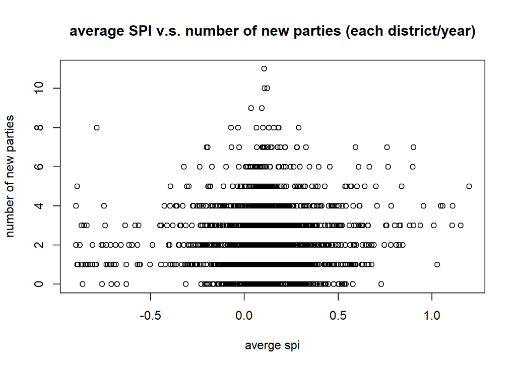

```r
#mark all the newly founded parties as 1, and old parties as 0
df2[,founded:= lapply(seq_len(nrow(df2)), function(i) if (df2$party_name[i] %in% as.list(strsplit(df2$founded[i], ","))[[1]]){founded = 0}else{founded = 1})]

#correct the data type
list <- df2$founded
list <- t(rbindlist(list(list)))
list <- data.frame(list)
df2$founded <- list

#sum the number of newly founded parties by each district and each year
df2 = df2[,c("district","year","founded","spi","party_issue","hhi")]
df2[,founded:= sum(founded), by = c("district","year")]

#get all unique issues
unique_issue = unique(df2$party_issue)[-3]
unique_issue[1] = "far_left"
unique_issue[3] = "ethnic_regional"
unique_issue[4] = "far_right"

#calculate the count of party issue
df2[, unique_issue[1] := as.numeric(party_issue == "far left")]
df2[, unique_issue[2] := as.numeric(party_issue == "liberal")]
df2[, unique_issue[3] := as.numeric(party_issue == "ethnic regional")]
df2[, unique_issue[4] := as.numeric(party_issue == "far right")]
df2[, unique_issue[5] := as.numeric(party_issue == "economic_nonfarming")]
df2[, unique_issue[6] := as.numeric(party_issue == "religious")]
df2[, unique_issue[7] := as.numeric(party_issue == "economic_farming")]

df2[, unique_issue[1] := sum(far_left), by = c("district","year")]
df2[, unique_issue[2] := sum(liberal), by = c("district","year")]
df2[, unique_issue[3] := sum(ethnic_regional), by = c("district","year")]
df2[, unique_issue[4] := sum(far_right), by = c("district","year")]
df2[, unique_issue[5] := sum(economic_nonfarming), by = c("district","year")]
df2[, unique_issue[6] := sum(religious), by = c("district","year")]
df2[, unique_issue[7] := sum(economic_farming), by = c("district","year")]

#remove duplicates
df2 <- df2[,-5]
df2 <- df2[!duplicated(df2)]

#calculate the average spi since the first period
df2[,count:= seq_len(.N), by = "district"]
df2[,spi:= cumsum(spi), by = "district"]
df2[,spi:= spi/count]
df2 = df2[,-13]

#produce the plot
plot(df2$spi,df2$founded, main="average SPI v.s. number of new parties (each district/year)",
ylab="number of new parties", xlab = "averge spi")
```

```r
#(b)
#find all unique focal_district
tmp <- unique(border$focal_district)

#form a huge list for all neighbors
df3 <- lapply(seq_along(tmp), function(i) border[border$focal_district == tmp[i]])

#create a huge empty list for each district and each year
for (i in seq_along(df3)){
    df3[[i]] = rbind(df3[[i]], list(df3[[i]]$focal_district[1],df3[[i]]$focal_district[1]))
    num = nrow(df3[[i]])
    tmp_df = df3[[i]]
    for (j in years[-1]){
      df3[[i]] = rbind(df3[[i]], tmp_df)
    }
    df3[[i]]$year = sort(rep(years,num))
}

#drew all the relative information
tmp_df = districts_adjrain[,c("district","year","spi")]

#import all spi values into the huge list we created
for (i in seq_along(df3)){
  for (j in seq_len(nrow(df3[[i]]))) {
    df3[[i]]$spi[j] = tmp_df[(tmp_df$year == df3[[i]]$year[j]) & (tmp_df$district == df3[[i]]$district[j]),]$spi[1]
  }
}

#Collepse it into a long list
df3 <- rbindlist(df3)
#order it by district and year
setorderv(df3,c("district","year"))
#find all prior spi values
df3[,prior_spi:= c(NA,spi[-.N]),by = "district"]

#draw self logged spi variable from the list
var_self = df3[df3$focal_district == df3$district]
y = var_self[,c(1,3,4)]
var_self = var_self[,c(1,3,5)]
#remove duplicates
var_self <- var_self[!duplicated(var_self)]
y <- y[!duplicated(y)]

#draw neighbor logged spi variable from the list
var_neib = df3[df3$focal_district != df3$district]
var_neib[, prior_spi:= mean(prior_spi, na.exclude = TRUE), by= c("focal_district","year")]
var_neib = var_neib[,c(1,3,5)]
colnames(var_neib)[3] = "neighbor"
#remove duplicates
var_neib <- var_neib[!duplicated(var_neib)]

#inner join two x variables with y varibles to form a table
data = left_join(y, var_self, by = c("focal_district","year"))
data = left_join(data, var_neib, by = c("focal_district","year"))
#remove empty values
data = na.omit(data)
colnames(data)[1] = "district"

#run the model
library(plm)
plm <- plm(spi ~ prior_spi + neighbor, data, effect = "twoways", model = "within", index = "district")

summary(plm)
```

```
## Twoways effects Within Model
##
## Call:
## plm(formula = spi ~ prior_spi + neighbor, data = data, effect = "twoways",
##     model = "within", index = "district")
##
## Unbalanced Panel: n = 218, T = 1-25, N = 2368
##
## Residuals:
##       Min.    1st Qu.     Median    3rd Qu.       Max.
## -1.6302538 -0.0538419 -0.0016525  0.0516690  1.5210059
##
## Coefficients:
##           Estimate Std. Error t-value  Pr(>|t|)
## prior_spi 0.510120   0.016912  30.163 < 2.2e-16 ***
## neighbor  0.502457   0.019455  25.826 < 2.2e-16 ***
## ---
## Signif. codes:  0 '***' 0.001 '**' 0.01 '*' 0.05 '.' 0.1 ' ' 1
##
## Total Sum of Squares:    555.66
## Residual Sum of Squares: 101.97
## R-Squared:      0.8165
## Adj. R-Squared: 0.7955
## F-statistic: 4725.34 on 2 and 2124 DF, p-value: < 2.22e-16
```

Based on the Anova report, SPI is not independent from one election period to the next within a district. Both prior_spi and neighbor spi are significant indicators for current spi. And the slopes are significantly large too, where the slope for two indicators are very similar. For both indicators, they hold a positive correlation with current spi, which mean current spi tend to simultaneously increase or decrease with prior_spi and neigbors’s spi.

```r
#(c)

#find all unique focal_district
tmp <- unique(border$focal_district)

#form a huge list for all neighbors
df4 <- lapply(seq_along(tmp), function(i) border[border$focal_district == tmp[i]])

#create a huge empty list for each district and each year
for (i in seq_along(df4)){
    df4[[i]] = rbind(df4[[i]], list(df4[[i]]$focal_district[1],df4[[i]]$focal_district[1]))
    num = nrow(df4[[i]])
    tmp_df = df4[[i]]
    for (j in years[-1]){
      df4[[i]] = rbind(df4[[i]], tmp_df)
    }
    df4[[i]]$year = sort(rep(years,num))
}

#get relavant information for moderate abnormal weathers
tmp_df2 <- districts_adjrain[,c("district","year","moderately_abnormal")]

#import all moderate abnormal weathers values into the huge list we created
for (i in seq_along(df4)){
  for (j in seq_len(nrow(df4[[i]]))) {
    df4[[i]]$moderately_abnormal[j] = tmp_df2[(tmp_df2$year == df4[[i]]$year[j]) & (tmp_df2$district == df4[[i]]$district[j]),]$moderately_abnormal[1]
  }
}

#Collepse it into a long list
df4 <- rbindlist(df4)
#order it by district and year
setorderv(df4,c("district","year"))
#find all prior moderate abnormal values
df4[,prior_m_abnormal:= c(NA,moderately_abnormal[-.N]),by = "district"]

#draw self logged spi variable from the list
var_self2 = df4[df3$focal_district == df4$district]
y2 = var_self2[,c(1,3,4)]
var_self2 = var_self2[,c(1,3,5)]
#remove duplicates
var_self2 <- var_self2[!duplicated(var_self2)]
y2 <- y2[!duplicated(y2)]

#draw neighbor logged spi variable from the list
var_neib2 = df4[df3$focal_district != df4$district]
var_neib2[, neighbor:= mean(prior_m_abnormal, na.exclude = TRUE), by= c("focal_district","year")]
var_neib2 = var_neib2[,c(1,3,6)]
#remove duplicates
var_neib2 <- var_neib2[!duplicated(var_neib2)]

#inner join two x variables with y varibles to form a table
data2 = left_join(y2, var_self2, by = c("focal_district","year"))
data2 = left_join(data2, var_neib2, by = c("focal_district","year"))
#remove empty values
data2 = na.omit(data2)
colnames(data2)[1] = "district"

#run the model
library(pglm)
pglm <- pglm(moderately_abnormal ~ prior_m_abnormal + neighbor, data2, effect = "twoways", model = "within", index = "district", family = "poisson")

summary(pglm)
```

```
## --------------------------------------------
## Maximum Likelihood estimation
## Newton-Raphson maximisation, 3 iterations
## Return code 1: gradient close to zero
## Log-Likelihood: -1765.888
## 2  free parameters
## Estimates:
##                  Estimate Std. error t value Pr(> t)
## prior_m_abnormal  0.58227    0.03068  18.979  <2e-16 ***
## neighbor          0.32432    0.03939   8.234  <2e-16 ***
## ---
## Signif. codes:  0 '***' 0.001 '**' 0.01 '*' 0.05 '.' 0.1 ' ' 1
## --------------------------------------------
```

```r
#Question2
#(a)
#import the new founded parties data
df5 <- df2
#join the moderate_abnormal data with founded party data
df5 = left_join(df5,data2,by = c("district","year"))
#clear all the NA rows
df5 = na.omit(df5)

#run the regression model using moderately_abnormal to predict founded parties
pglm2 <- pglm(founded ~ moderately_abnormal, data = df5, effect = "twoways", model = "within", index = "district", family = "poisson")

summary(pglm2)
```

```
## --------------------------------------------
## Maximum Likelihood estimation
## Newton-Raphson maximisation, 2 iterations
## Return code 2: successive function values within tolerance limit
## Log-Likelihood: -3405.411
## 1  free parameters
## Estimates:
##                     Estimate Std. error t value Pr(> t)
## moderately_abnormal -0.01374    0.01563  -0.879   0.379
## --------------------------------------------
```

The coefficient is not very statistical significant, but based on slope, graph and correlation seems there’s a negative relationship, saying that, when there are more abnormal weathers, new parties tend not to form.

```r
#plot the count of party issue to see if there are relationships
library(ggplot2)
gg <- df5[,c(6:12,13)]
gg <- cor(gg)
gg
```

```
##                        far_left     liberal ethnic_regional   far_right
## far_left             1.00000000  0.20818728      0.20782067  0.03572537
## liberal              0.20818728  1.00000000      0.09132494 -0.17108117
## ethnic_regional      0.20782067  0.09132494      1.00000000 -0.14161978
## far_right            0.03572537 -0.17108117     -0.14161978  1.00000000
## economic_nonfarming  0.17123941  0.08059613      0.02090569 -0.03305664
## religious            0.10066913 -0.02254894      0.03222307  0.10220741
## economic_farming     0.19375672  0.09204239      0.05713921  0.04460894
## moderately_abnormal -0.07644764 -0.22818536     -0.12685374  0.09997387
##                     economic_nonfarming   religious economic_farming
## far_left                     0.17123941  0.10066913      0.193756721
## liberal                      0.08059613 -0.02254894      0.092042394
## ethnic_regional              0.02090569  0.03222307      0.057139207
## far_right                   -0.03305664  0.10220741      0.044608943
## economic_nonfarming          1.00000000  0.08405102      0.021357736
## religious                    0.08405102  1.00000000      0.023532735
## economic_farming             0.02135774  0.02353273      1.000000000
## moderately_abnormal         -0.05928339  0.03619792     -0.004904827
##                     moderately_abnormal
## far_left                   -0.076447642
## liberal                    -0.228185355
## ethnic_regional            -0.126853737
## far_right                   0.099973874
## economic_nonfarming        -0.059283388
## religious                   0.036197917
## economic_farming           -0.004904827
## moderately_abnormal         1.000000000
```

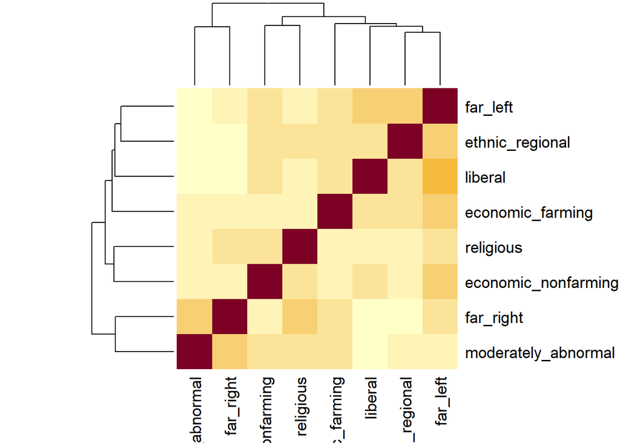

```r
heatmap(gg)
```

```r
#(b)
#run the regression model using moderately_abnormal to predict founded parties
pglm2 <- pglm(founded ~ moderately_abnormal + neighbor, data = df5, effect = "twoways", model = "within", index = "district", family = "poisson")

summary(pglm2)
```

```
## --------------------------------------------
## Maximum Likelihood estimation
## Newton-Raphson maximisation, 2 iterations
## Return code 2: successive function values within tolerance limit
## Log-Likelihood: -3405.211
## 2  free parameters
## Estimates:
##                      Estimate Std. error t value Pr(> t)
## moderately_abnormal -0.002456   0.023703  -0.104   0.917
## neighbor            -0.018473   0.029211  -0.632   0.527
## --------------------------------------------
```

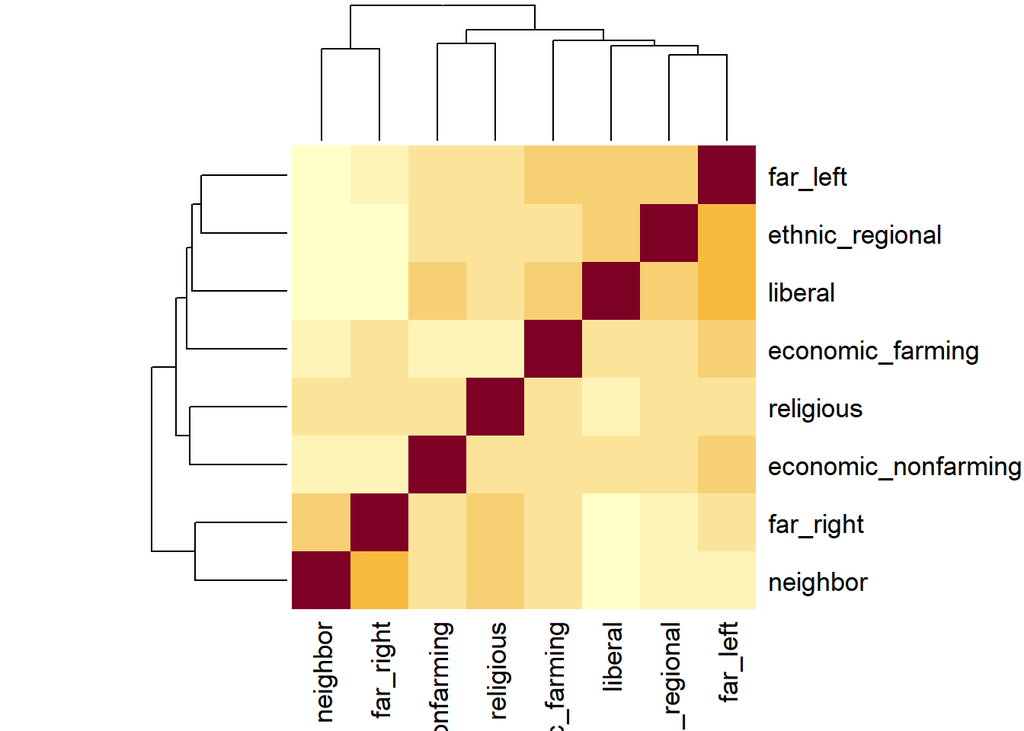

```r
#plot the count of party issue to see if there are relationships
gg <- df5[,c(6:12,15)]
gg <- cor(gg)
heatmap(gg)
```

```r
#Question3
#run the regression model using moderately_abnormal to predict founded parties
pglm3 <- pglm(hhi ~ moderately_abnormal + neighbor, data = df5, effect = "twoways", model = "within", index = "district", family = "poisson")

summary(pglm3)
```

```
## --------------------------------------------
## Maximum Likelihood estimation
## Newton-Raphson maximisation, 2 iterations
## Return code 2: successive function values within tolerance limit
## Log-Likelihood: -266813.9
## 2  free parameters
## Estimates:
##                      Estimate Std. error t value Pr(> t)
## moderately_abnormal 0.0009033  0.0005695   1.586   0.113
## neighbor            0.0058428  0.0007056   8.281  <2e-16 ***
## ---
## Signif. codes:  0 '***' 0.001 '**' 0.01 '*' 0.05 '.' 0.1 ' ' 1
## --------------------------------------------
```

Based on the coefficients we clearly see that neighbor is statistically significant, moderately_abnormal, although not statistically significant, the t-statistics is not too bad, so it would still offer valueable infomation. As we see. they both have a possitve correlation with HHI or political concentration, which means as the number of abnormal weathers increasing HHI incerase too. It might be because, during abnormal weathers, large national-scale parties that have difficulty responding to the needs of affected regions. So the political powers are more concentrated to local parties.

```r
#Question4
#get the edge list of neighborhood information
df6 <- border

#create a igraph of all edges
g = graph.data.frame(df6, directed = FALSE)
#remove multiple and self loop
g = simplify(g,remove.multiple = TRUE,remove.loops = TRUE)

#use ego graphs to find all the neighborhoods of two distances in each years
ego_graph <-lapply(seq_len(length(V(g)$name)), function(i) make_ego_graph(g, order = 2, mode = 'all', nodes = V(g)$name[i]))

#create a huge list of all the neiborhood information with in two neighbor distances
ego_list <- lapply(seq_along(ego_graph), function(i) data.table(V(ego_graph[[i]][[1]])$name))

#create a index for the center of all neighborhood lists
index <- V(g)$name

#expend the current lists to even longer empty lists for each district and each year
for (i in seq_along(ego_list)){
    ego_list[[i]]$year = rep(0,nrow(ego_list[[i]]))
    num = nrow(ego_list[[i]])
    tmp_df = ego_list[[i]]
    for (j in years[-1]){
      ego_list[[i]] = rbind(ego_list[[i]], tmp_df)
    }
    ego_list[[i]]$year = sort(rep(years,num))
}

#find all the parties that competed in a district at a specific year
#first, get relevant data
df6 <- districts[,c(1,2,7)]
colnames(df6)[3] <- "party"
#remove dupelicates
df6 <- df6[!duplicated(df6)]
#find all unique district
tmp <- unique(df6$district)
#create a huge list for each district
df6 <- lapply(seq_along(tmp), function(i) df6[df6$district == tmp[i]])

#produce a party list for each year and each district, which includes all the parties that competed in the district prior
for (i in seq_along(df6)){
  setorderv(df6[[i]],"year")
  for (j in seq_len(nrow(df6[[i]]))){
    if(j>1){
      df6[[i]][j,"party"] = paste(df6[[i]]$party[j],df6[[i]]$party[j-1],sep = ",")
    }
    else{
      df6[[i]][j,"party"] = df6[[i]][j,"party"]
    }
  }
  df6[[i]][1,"party"] = "none"
}
df6 = rbindlist(df6)
setorderv(df6,c("district","year"))
df6[,party:= c(NA,party[-.N]),by = "district"]
df6[,party := party[which.min(nchar(party))],by = c("district","year")]

#remove dupelicates
df6 <- df6[!duplicated(df6)]
na.omit(df6)
```

[output not shown]

```r
#import the party name list we create to the empty neighborhood lists
for (i in seq_along(ego_list)){
  setorderv(ego_list[[i]],"year")
  colnames(ego_list[[i]])[1] <- "district"
  ego_list[[i]]$party <- rep("none", nrow(ego_list[[i]]))
  for (j in seq_len(nrow(ego_list[[i]]))){
    cond = sum((df6$district==ego_list[[i]]$district[j])&(df6$year==ego_list[[i]]$year[j]))
    if (cond == 1){
    ego_list[[i]][j,"party"] = df6[(df6$district==ego_list[[i]]$district[j])&(df6$year==ego_list[[i]]$year[j])]$party
    }
  }
  ego_list[[i]] = ego_list[[i]][ego_list[[i]]$party != "none"]
}

#combine the rows within same neighborhood and same year
for (i in seq_along(ego_list)){
  ego_list[[i]] = ego_list[[i]][,c(2,3)]
  ego_list[[i]][,party2:= c(NA,party[-.N]), by = "year"]
  ego_list[[i]][,party:= paste(party,party2,sep = ","), by = "year"]
  ego_list[[i]][,party := party[which.max(nchar(party))],by = c("year")]
  ego_list[[i]] = ego_list[[i]][,c(1:2)]
  ego_list[[i]] = ego_list[[i]][!duplicated(ego_list[[i]])]
}
```

```r
#get all party names for each year, and remove all dupelicates
data3 <- districts[,c(1,2,7)]
data3 = data3[!duplicated(data3)]

#check if each party has compete in the previous round
for (i in seq_len(nrow(data3))){
  num = match(data3$district[i],index)
  tmp_list = ego_list[[num]][ego_list[[num]]$year == data3$year[i],"party"]
  if (is.character(tmp_list[[1]])){
  tmp_list = as.list(strsplit(tmp_list[[1]], ","))
  }
  else{tmp_list = "empty"}
  tmp_list[tmp_list == ""] = "empty"
  if(data3$party_name[i] %in% unlist(tmp_list)){
    data3$competed[i] = 1
  }
  else{
    data3$competed[i] = 0
  }
}

#combine the data with other variables
compete = left_join(data3,df5, by = c("district","year"))
#clean NA
compete = na.omit(compete)
colSums(is.na(compete))
```

```
##            district                year          party_name            competed
##                   0                   0                   0                   0
##             founded                 spi                 hhi            far_left
##                   0                   0                   0                   0
##             liberal     ethnic_regional           far_right economic_nonfarming
##                   0                   0                   0                   0
##           religious    economic_farming moderately_abnormal    prior_m_abnormal
##                   0                   0                   0                   0
##            neighbor
##                   0
```

```r
#run the model to predict the  likelihood of new political parties being founded in a district that have not contested an election in a neighboring district in any previous election period

pglm4 <- pglm(competed ~ moderately_abnormal + neighbor, data = compete, effect = "twoways", model = "within", index = "district", family = "poisson")

summary(pglm4)
```

```
## --------------------------------------------
## Maximum Likelihood estimation
## Newton-Raphson maximisation, 2 iterations
## Return code 1: gradient close to zero
## Log-Likelihood: -10376.89
## 2  free parameters
## Estimates:
##                      Estimate Std. error t value Pr(> t)
## moderately_abnormal -0.005593   0.019782  -0.283  0.7774
## neighbor            -0.050021   0.024397  -2.050  0.0403 *
## ---
## Signif. codes:  0 '***' 0.001 '**' 0.01 '*' 0.05 '.' 0.1 ' ' 1
## --------------------------------------------
```

Based on the coefficients we clearly see that neighbor is statistically significant, moderately_abnormal is not statistically significant, and the slope is small. As we see. they both have a negative correlation with whether a party has competed in neighbor districts, which means as the number of abnormal weathers increasing likelihood of a party competed in neighbor districts decrease. It might be because, during abnormal weathers, less parties have power to engage in nearby areas, so likehood decrease.

```r
#run the model to predict the likelihood of a new candidate contesting an election in a district, that has contested an election within a distance of two neighboring district in any previous election period

pglm5 <- pglm(founded ~ moderately_abnormal + neighbor, data = compete, effect = "twoways", model = "within", index = "district", family = "poisson")

summary(pglm5)
```

```
## --------------------------------------------
## Maximum Likelihood estimation
## Newton-Raphson maximisation, 2 iterations
## Return code 2: successive function values within tolerance limit
## Log-Likelihood: -20042.48
## 2  free parameters
## Estimates:
##                     Estimate Std. error t value Pr(> t)
## moderately_abnormal  0.01023    0.01014   1.009   0.313
## neighbor            -0.01586    0.01241  -1.278   0.201
## --------------------------------------------
```

Based on the coefficients we clearly see that both are not statistically significant. As we see. neighbor has a negative correlation with whether a candiate competed in neighbor districts, and moderately_abnormal has a positve correlation with whether a candiate competed in neighbor districts, which means as the number of abnormal weathers in neighbor areas increasing likelihood of a party competed in neighbor districts decrease, and as the number of abnormal weathers in local areas increasing likelihood of a party competed in neighbor districts increase.

```r
#Question5
#(1)

#calculate HHI for party issue
#calculate HHI2 - The Herfindahl Index for party issues
library(hhi)
compete[, count:=seq_len(.N)]
compete[,hhi2 := sum(far_left,liberal,ethnic_regional,far_right,economic_nonfarming,religious,economic_farming), by = "count"]

compete[,far_left := ((far_left*100)/hhi2)^2, by = "count"]
compete[,liberal := ((liberal*100)/hhi2)^2, by = "count"]
compete[,ethnic_regional := ((ethnic_regional*100)/hhi2)^2, by = "count"]
compete[,far_right := ((far_right*100)/hhi2)^2, by = "count"]
compete[,economic_nonfarming := ((economic_nonfarming*100)/hhi2)^2, by = "count"]
compete[,religious := ((religious*100)/hhi2)^2, by = "count"]
compete[,economic_farming := ((economic_farming*100)/hhi2)^2, by = "count"]

compete[,hhi2 := sum(far_left,liberal,ethnic_regional,far_right,economic_nonfarming,religious,economic_farming), by = "count"]
```

```r
#run the model to predict the likelihood of a new candidate contesting an election in a district, that has contested an election within a distance of two neighboring district in any previous election period

pglm6 <- pglm(competed ~ hhi2, data = compete, effect = "twoways", model = "within", index = "district", family = "poisson")

summary(pglm6)
```

```
## --------------------------------------------
## Maximum Likelihood estimation
## Newton-Raphson maximisation, 2 iterations
## Return code 2: successive function values within tolerance limit
## Log-Likelihood: -10376.11
## 1  free parameters
## Estimates:
##        Estimate Std. error t value Pr(> t)
## hhi2 -1.153e-05  5.502e-06  -2.096  0.0361 *
## ---
## Signif. codes:  0 '***' 0.001 '**' 0.01 '*' 0.05 '.' 0.1 ' ' 1
## --------------------------------------------
```

```r
#(b)

#I don't have enough time to finish, but this could be done using the same method/same loop I used in question1 and question4, simply by adding the winning team into the huge list I created.

#After adding the winning teams, I can create a list of winning team in the neiborhood.
#Then I can filter the origin dataset using that to find all the districts that the party competed in but didn't win.
#then I sum up that number and save it as a column, and later on to use it run the model.

#Here's the simplied version that didn't use the huge list I created.
#Because I don't have the huge list, I can only determne if the party win or lose instead of the totall number of lose.
#I will use this binary varible of whether win or lose to do a simple example to potentially show partial processes of the complete version, although it's impossible to really get to the idea..

#create a table that marks districts by both the year of this period and last period
df7 <- districts[,c(1,2,7,10)]
df7[,last_period:= year]
df7[df7$year==1951,"last_period"] = 0
df7[df7$year==1957,"last_period"] = 1951
df7[df7$year==1962,"last_period"] = 1957
df7[df7$year==1967,"last_period"] = 1962
df7[df7$year==1971,"last_period"] = 1967
df7[df7$year==1977,"last_period"] = 1971
df7[df7$year==1980,"last_period"] = 1977
df7[df7$year==1984,"last_period"] = 1980
df7[df7$year==1989,"last_period"] = 1984
df7[df7$year==1991,"last_period"] = 1989
df7[df7$year==1996,"last_period"] = 1991
df7[df7$year==1998,"last_period"] = 1996
df7[df7$year==1999,"last_period"] = 1998
df7 = df7[df7$last_period!=0,]

#Find all the parties that competed in the nearby nerighborhood
# if the party has competed last period and didn't win then mark as 1
for (i in seq_len(nrow(df7))){
  # if the party has competed last period and didn't win then mark as 1
  cond1 = df7$party_name[i] %in% df7$party_name[df7$year==df7$last_period[i]]
  cond2 = df7$vote_count[i] < max(df7$vote_count[df7$year==df7$last_period[i]])
  #Find all the parties that competed in the nearby nerighborhood
  cond3 = df7$party_name[i] %in%  compete$party_name[compete$year==df7$last_period[i]]
  if ((cond1+cond2 + cond3) == 3){
    df7[i,"lose"] = 1
  }
  else{
    df7[i,"lose"] = 0
  }
}

#join all the variable together
df7 <- left_join(df7,compete, by = c("year","party_name","district"))

#remove dupelicates
df7 = df7[!duplicated(df7)]
#clean NA
df7 = na.omit(df7)
colSums(is.na(df7))
```

```
##            district                year          party_name          vote_count
##                   0                   0                   0                   0
##         last_period                lose            competed             founded
##                   0                   0                   0                   0
##                 spi                 hhi            far_left             liberal
##                   0                   0                   0                   0
##     ethnic_regional           far_right economic_nonfarming           religious
##                   0                   0                   0                   0
##    economic_farming moderately_abnormal    prior_m_abnormal            neighbor
##                   0                   0                   0                   0
##               count                hhi2
##                   0                   0
```

```r
#run the model
pglm7 <- pglm(competed ~ lose, data = df7, effect = "twoways", model = "within", index = "district", family = "poisson")

summary(pglm7)
```

```
## --------------------------------------------
## Maximum Likelihood estimation
## Newton-Raphson maximisation, 2 iterations
## Return code 1: gradient close to zero
## Log-Likelihood: -25031.28
## 1  free parameters
## Estimates:
##      Estimate Std. error t value Pr(> t)
## lose  1.48563    0.03226   46.05  <2e-16 ***
## ---
## Signif. codes:  0 '***' 0.001 '**' 0.01 '*' 0.05 '.' 0.1 ' ' 1
## --------------------------------------------
```

Based on the coefficients we clearly see that lose is statistically significant. Also we can see. lose has a very significant positive correlation with whether a party has competed in neighbor districts, Therefore, I prefer the second theory, where new parties are more likely to diffuse into areas where a national party has suffered a recent loss, creating a power vacuum.